# SIG29 dGEP Analysis: waggr

EYW

2026-08-14

# Goal

Downstream analysis of the SIG18 dGEP scores projected onto SIG29 (see `01_dGEP_scoring_SIG29.ipynb`).

# Import

```r
library(tidyverse)
```

```r
library(patchwork)
library(broom)
library(sandwich)
library(ggrepel)
library(RColorBrewer)
library(pheatmap)
library(gridExtra)
knitr::opts_chunk$set(echo = TRUE, warning = FALSE, message = FALSE)

source("../../functions/r_custom/plotting_fxns.R")
theme_set(theme_Publication())

# ---- config ----
score_method <- "waggr"
sig_alpha    <- 0.1
proj_dir <- "../../analysis_outs/inference_SIG18"
out_dir  <- proj_dir

# SIG18 sPCA/dGEP outputs this analysis reads (sibling repo)
sig18_dir             <- "/data1/rudenska/EYW/git_projects/SIG18"
sig18_lm_scored_clean <- file.path(sig18_dir, "analysis_outs/spca/lm_scored_zscore_degs_alpha10.0_sPCA_clean.csv")
sig18_lm_fit          <- file.path(sig18_dir, "analysis_outs/spca/lm_fit_zscore_degs_alpha10.0_sPCA.csv")
```

```r
obs <- read_csv(file.path(proj_dir, "waggr_scored_obs_SIG29.csv"))

# score feature columns (SIG18_*) and a tidy condition factor (none_none = reference)
feature_cols <- grep("^SIG18_", colnames(obs), value = TRUE)

obs <- obs %>%
  mutate(
    cond      = paste0(ligand1, "_", ligand2),
    cond      = relevel(factor(cond), ref = "none_none"),
    replicate = factor(replicate)
  )

# map each feature -> program id
feature_map <- tibble(feature = feature_cols) %>%
  mutate(program = str_extract(feature, "comp_[0-9]+"))

cat(score_method, ":", length(feature_cols), "SIG18 program features\n")
```

```
## waggr : 56 SIG18 program features
```

# Interaction effects (order-independent LM)

Because `ligand1`/`ligand2` are arbitrary slots (the same ligand could in principle appear in either slot, and SIG29’s own combos are always `TGFb_<member>`), each program score is regressed on **slot-independent** ligand-presence indicators (`lig_<L>`) plus one indicator per **unordered** ligand pair (`pair_<A>_<B>`), controlling for donor (`replicate`), with `none_none` as the reference: `score ~ sum(lig_<L>) + sum(pair_<A>_<B>) + replicate`. `pair_<A>_<B>` is the symmetric interaction term; robust (HC3) SEs are used and p-values are BH-adjusted.

```r
# per-sample scaled program scores (one row per ligand1_ligand2_replicate)
score_mat <- obs %>%
  mutate(sample = paste(ligand1, ligand2, replicate, sep = "_")) %>%
  mutate(across(all_of(feature_cols), ~ as.numeric(scale(.x)))) %>%
  column_to_rownames("sample") %>%
  dplyr::select(all_of(feature_cols)) %>%
  as.matrix()

# ---- order-independent ligand design ----
# per-sample ligand membership (drop "none")
samp_lig <- obs %>%
  mutate(sample = paste(ligand1, ligand2, replicate, sep = "_")) %>%
  dplyr::select(sample, ligand1, ligand2) %>%
  pivot_longer(c(ligand1, ligand2), values_to = "ligand") %>%
  filter(ligand != "none") %>%
  distinct(sample, ligand)

# main-effect indicators: lig_<LIGAND> = 1 if present in either slot
main_ind <- samp_lig %>%
  transmute(sample, term = paste0("lig_", ligand), val = 1L) %>%
  pivot_wider(names_from = term, values_from = val, values_fill = 0L)

# unordered pairwise indicators: pair_<A>_<B> (A,B sorted) = 1 if both present
pair_ind <- samp_lig %>%
  group_by(sample) %>%
  filter(n() == 2) %>%
  summarise(term = paste0("pair_", paste(sort(ligand), collapse = "_")), .groups = "drop") %>%
  mutate(val = 1L) %>%
  pivot_wider(names_from = term, values_from = val, values_fill = 0L)

# replicate (donor/batch)
rep_df <- obs %>%
  mutate(sample = paste(ligand1, ligand2, replicate, sep = "_")) %>%
  distinct(sample, replicate)

# per-sample design + symmetric model formula (none_none = reference)
design <- tibble(sample = rownames(score_mat)) %>%
  left_join(main_ind, by = "sample") %>%
  left_join(pair_ind, by = "sample") %>%
  left_join(rep_df, by = "sample") %>%
  mutate(across(c(starts_with("lig_"), starts_with("pair_")), ~ replace_na(.x, 0L)))

pred_terms    <- design %>% dplyr::select(starts_with("lig_"), starts_with("pair_")) %>% names()
model_formula <- reformulate(c(pred_terms, "replicate"), response = "score")

# long format: scaled program scores joined to the symmetric design
int_df <- as.data.frame(score_mat) %>%
  rownames_to_column("sample") %>%
  pivot_longer(cols = all_of(feature_cols), names_to = "feature", values_to = "score") %>%
  left_join(design, by = "sample")
```

OLS fit with robust (HC3) SEs per program; BH adjustment across all terms.

```r
.robust_vcov <- function(mod) sandwich::vcovHC(mod, type = "HC3")
.tidy_ols_hc <- function(mod) broom::tidy(mod, conf.int = TRUE, vcov = .robust_vcov)

# models are kept (`lm_models`) so per-condition contrasts can be computed from
# the same fits further below (see "Condition effects")
lm_models <- int_df %>%
  group_by(feature) %>%
  nest() %>%
  mutate(model = map(data, ~ lm(model_formula, data = .x))) %>%
  ungroup()

lm_int <- lm_models %>%
  mutate(tidy = map(model, .tidy_ols_hc)) %>%
  dplyr::select(feature, tidy) %>%
  unnest(tidy) %>%
  left_join(feature_map, by = "feature") %>%
  mutate(p_adj = p.adjust(p.value, method = "BH"))

write_csv(lm_int, file.path(out_dir, paste0("scoreInteractionLM_", score_method, "_SIG29.csv")))
```

## Remove replicate-driven programs

```r
# drop any program whose most significant association is a replicate (donor) term
bad_rep_feats <- lm_int %>%
  group_by(feature) %>%
  slice_min(p_adj, with_ties = FALSE) %>%
  filter(grepl("replicate", term)) %>%
  pull(feature)

lm_int_filtered <- lm_int %>% filter(!(feature %in% bad_rep_feats))
length(bad_rep_feats)
```

```
## [1] 2
```

## Classify interaction effects

```r
# single-ligand main effects (slot-independent: lig_<LIGAND>)
main_eff <- lm_int_filtered %>%
  filter(grepl("^lig_", term)) %>%
  transmute(feature, program, ligand = sub("^lig_", "", term), estimate, p_adj)
l1 <- main_eff %>% transmute(feature, ligand1 = ligand,
                             estimate_ligand1 = estimate, p_adj_ligand1 = p_adj)
l2 <- main_eff %>% transmute(feature, ligand2 = ligand,
                             estimate_ligand2 = estimate, p_adj_ligand2 = p_adj)

# map each unordered pair back to its canonical ligand1_ligand2 label (metadata order)
combo_canon <- obs %>%
  dplyr::filter(ligand1 != "none", ligand2 != "none") %>%
  dplyr::distinct(ligand1, ligand2) %>%
  dplyr::mutate(pair = purrr::map2_chr(ligand1, ligand2,
                                       ~ paste(sort(c(.x, .y)), collapse = "_")))

# unordered pairwise interaction effects (pair_<A>_<B>)
int <- lm_int_filtered %>%
  filter(grepl("^pair_", term)) %>%
  mutate(pair = sub("^pair_", "", term)) %>%
  left_join(combo_canon, by = "pair") %>%
  transmute(feature, program, ligand1, ligand2,
            interaction = paste0(ligand1, "_", ligand2),
            estimate_interaction = estimate, p_adj_interaction = p_adj)

lm_int_scored <- int %>%
  left_join(l1, by = c("feature", "ligand1"), relationship = "many-to-many") %>%
  left_join(l2, by = c("feature", "ligand2"), relationship = "many-to-many") %>%
  mutate(
    estimate_total    = estimate_ligand1 + estimate_ligand2 + estimate_interaction,
    interaction_score = case_when(p_adj_interaction > sig_alpha ~ 0,
                                  TRUE ~ estimate_interaction / estimate_total),
    interaction_class = case_when(
      p_adj_interaction <= sig_alpha & estimate_total > 0 & interaction_score > 0 ~ "synergy positive",
      p_adj_interaction <= sig_alpha & estimate_total < 0 & interaction_score > 0 ~ "synergy negative",
      p_adj_interaction <= sig_alpha & interaction_score < 0                      ~ "buffering",
      TRUE                                                                        ~ "none")) %>%
  arrange(interaction, feature)

write_csv(lm_int_scored, file.path(out_dir, paste0("scoreInteractionScored_", score_method, "_SIG29.csv")))
lm_int_scored %>% filter(interaction_class != "none") %>% arrange(p_adj_interaction) %>% head(10)
```

```
## # A tibble: 10 × 14
##    feature             program ligand1 ligand2 interaction estimate_interaction
##    <chr>               <chr>   <chr>   <chr>   <chr>                      <dbl>
##  1 SIG18_waggr_comp_30 comp_30 TGFb    OX40L   TGFb_OX40L                 -2.27
##  2 SIG18_waggr_comp_45 comp_45 TGFb    OX40L   TGFb_OX40L                 -2.60
##  3 SIG18_waggr_comp_30 comp_30 TGFb    TL1A    TGFb_TL1A                  -1.98
##  4 SIG18_waggr_comp_45 comp_45 TGFb    TL1A    TGFb_TL1A                  -2.35
##  5 SIG18_waggr_comp_15 comp_15 TGFb    OX40L   TGFb_OX40L                 -2.08
##  6 SIG18_waggr_comp_19 comp_19 TGFb    OX40L   TGFb_OX40L                 -2.24
##  7 SIG18_waggr_comp_6  comp_6  TGFb    OX40L   TGFb_OX40L                 -1.43
##  8 SIG18_waggr_comp_30 comp_30 TGFb    TNF     TGFb_TNF                   -1.90
##  9 SIG18_waggr_comp_35 comp_35 TGFb    OX40L   TGFb_OX40L                 -2.24
## 10 SIG18_waggr_comp_6  comp_6  TGFb    TL1A    TGFb_TL1A                  -1.37
## # ℹ 8 more variables: p_adj_interaction <dbl>, estimate_ligand1 <dbl>,
## #   p_adj_ligand1 <dbl>, estimate_ligand2 <dbl>, p_adj_ligand2 <dbl>,
## #   estimate_total <dbl>, interaction_score <dbl>, interaction_class <chr>
```

## Number of interaction programs per ligand pair

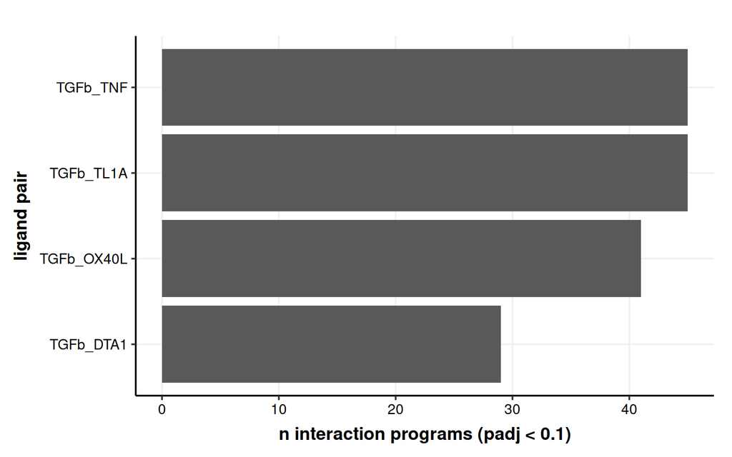

```r
lm_int_scored %>%
  mutate(sig = interaction_class != "none") %>%
  group_by(interaction) %>%
  summarise(n_sig = sum(sig), .groups = "drop") %>%
  ggplot(aes(x = reorder(interaction, n_sig), y = n_sig)) +
  geom_col() +
  coord_flip() +
  labs(x = "ligand pair", y = paste0("n interaction programs (padj < ", sig_alpha, ")"))
```

# Condition effects (lm contrasts)

Each SIG29 condition’s effect vs. the `none_none` control is a linear combination of the model coefficients fit above: for a single-ligand condition it is the `lig_<L>` coefficient; for a combo it is `lig_<A> + lig_<B> + pair_<A>_<B>`. Estimates and robust (HC3) standard errors are taken from the same fits, so the combo columns get a proper test rather than being read off a single coefficient. p-values are BH-adjusted across all program x condition contrasts at once.

```r
# ligand membership per condition (none_none = control, excluded)
cond_ligands <- obs %>%
  distinct(ligand1, ligand2) %>%
  mutate(cond = paste0(ligand1, "_", ligand2)) %>%
  filter(cond != "none_none") %>%
  mutate(ligands = map2(ligand1, ligand2, ~ setdiff(c(.x, .y), "none")))

# contrast vector (in coefficient space) for one condition
contrast_terms <- function(ligs) {
  c(paste0("lig_", ligs),
    if (length(ligs) == 2) paste0("pair_", paste(sort(ligs), collapse = "_")))
}

# est = c'b, se = sqrt(c'Vc) with V = HC3; two-sided t-test on the model's df
condition_contrast <- function(mod, terms) {
  b <- coef(mod)
  V <- .robust_vcov(mod)
  cvec <- setNames(as.numeric(names(b) %in% terms), names(b))
  est <- sum(cvec * b)
  se  <- sqrt(drop(t(cvec) %*% V %*% cvec))
  tibble(estimate = est, std.error = se,
         p.value = 2 * pt(abs(est / se), df = df.residual(mod), lower.tail = FALSE))
}

cond_assoc <- lm_models %>%
  dplyr::select(feature, model) %>%
  tidyr::crossing(cond_ligands %>% dplyr::select(cond, ligands)) %>%
  mutate(res = map2(model, ligands, ~ condition_contrast(.x, contrast_terms(.y)))) %>%
  dplyr::select(feature, cond, res) %>%
  unnest(res) %>%
  left_join(feature_map, by = "feature") %>%
  mutate(p_adj = p.adjust(p.value, method = "BH"))

write_csv(cond_assoc, file.path(out_dir, paste0("scoreConditionLM_", score_method, "_SIG29.csv")))
cond_assoc %>% arrange(p_adj) %>% head(10)
```

```
## # A tibble: 10 × 7
##    feature             cond       estimate std.error  p.value program    p_adj
##    <chr>               <chr>         <dbl>     <dbl>    <dbl> <chr>      <dbl>
##  1 SIG18_waggr_comp_41 TGFb_TNF       2.40    0.0679 3.80e-24 comp_41 6.39e-22
##  2 SIG18_waggr_comp_49 TGFb_none      2.42    0.0661 1.57e-24 comp_49 6.39e-22
##  3 SIG18_waggr_comp_7  TGFb_TNF       2.91    0.0818 3.19e-24 comp_7  6.39e-22
##  4 SIG18_waggr_comp_41 TGFb_OX40L     2.25    0.0666 1.26e-23 comp_41 1.58e-21
##  5 SIG18_waggr_comp_31 TGFb_OX40L     2.39    0.0796 2.73e-22 comp_31 2.75e-20
##  6 SIG18_waggr_comp_34 TGFb_TL1A      2.53    0.0898 1.49e-21 comp_34 1.25e-19
##  7 SIG18_waggr_comp_54 TGFb_TNF       2.92    0.104  1.80e-21 comp_54 1.30e-19
##  8 SIG18_waggr_comp_41 TGFb_TL1A      2.29    0.0838 3.41e-21 comp_41 2.15e-19
##  9 SIG18_waggr_comp_3  TGFb_TL1A      2.84    0.107  6.85e-21 comp_3  3.84e-19
## 10 SIG18_waggr_comp_4  TGFb_TL1A      2.56    0.0981 1.12e-20 comp_4  5.64e-19
```

# Effect-size heatmap: TGFb/TNF class programs

Two panels sharing rows, both showing **linear-model estimates** on z-scaled scores (SDs of that program’s score within its experiment), so they are on comparable scales:

- **left** — SIG29 condition effects vs. `none_none` from the contrasts above, starred by their globally BH-adjusted p-values.
- **right** — the same programs in the original SIG18 ligand experiment, from SIG18’s `ligand1 * ligand2` model: the `TGFb` and `TNF` main effects and their combined effect (`TGFb` + `TNF` + interaction, SIG18’s `estimate_total_interaction_model`). Left unstarred because no single coefficient tests that summed combined effect.

```r
lmScored <- read_csv(sig18_lm_scored_clean) %>%
  filter(interaction == "TGFb_TNF")
```

```r
n_components <- 6
# top `n` components where `p_col`/`est_col` (one ligand's main effect) clears
# est_threshold/p_threshold and the other ligand's main effect (other_*) doesn't
# -- i.e. a ligand-specific (not shared) effect
ligand_only_components <- function(df, p_col, est_col, other_p_col, other_est_col,
                                    p_threshold = 0.1, est_threshold = 0.5, n = n_components) {
  df %>%
    filter(!grepl("synergy positive", interaction_class)) %>%
    filter(.data[[p_col]] < p_threshold & .data[[est_col]] > est_threshold) %>%
    filter(!(.data[[other_p_col]] < p_threshold & .data[[other_est_col]] > 0)) %>%
    slice_min(.data[[p_col]], n = n) %>%
    pull(component)
}

tgfb_tnf_synergy <- lmScored %>%
  filter(interaction_class == "synergy positive") %>%
  slice_min(p_adj_interaction, n = n_components) %>%
  pull(component)

tgfb_only <- ligand_only_components(lmScored, "p_adj_ligand1", "estimate_ligand1", "p_adj_ligand2", "estimate_ligand2")
tnf_only  <- ligand_only_components(lmScored, "p_adj_ligand2", "estimate_ligand2", "p_adj_ligand1", "estimate_ligand1")

comp_class <- bind_rows(
  tibble(component = tgfb_tnf_synergy, class = "synergy positive"),
  tibble(component = tgfb_only,        class = "tgfb"),
  tibble(component = tnf_only,         class = "tnf")
) %>%
  distinct(component, .keep_all = TRUE)
```

## Building the matrices

```r
# programs x levels matrix from a long data frame, in the requested row/col order
as_program_matrix <- function(df, col, value, row_order, col_order = NULL) {
  mat <- df %>%
    filter(program %in% row_order) %>%
    dplyr::select(program, all_of(c(col, value))) %>%
    pivot_wider(names_from = all_of(col), values_from = all_of(value)) %>%
    column_to_rownames("program") %>%
    as.matrix()
  if (is.null(col_order)) col_order <- colnames(mat)
  mat[row_order, col_order, drop = FALSE]
}

# Adjusted p-values -> significance stars, on the conventional 0.05/0.01/0.001
# ladder (deliberately NOT `sig_alpha`, the looser 0.1 cutoff used for labelling
# programs elsewhere in this notebook).
stars_from_padj <- function(p) {
  stars_vec <- case_when(
    is.na(as.vector(p))  ~ "",
    as.vector(p) < 0.001 ~ "***",
    as.vector(p) < 0.01  ~ "**",
    as.vector(p) < 0.05  ~ "*",
    TRUE                 ~ "")
  matrix(stars_vec, nrow = nrow(p), dimnames = dimnames(p))
}

# row annotation + row order, shared by both panels
ann_row <- comp_class %>%
  arrange(class, component) %>%
  column_to_rownames("component")
row_order <- rownames(ann_row)
gaps_row  <- head(cumsum(table(ann_row$class)), -1)

n_classes <- n_distinct(ann_row$class)
class_colors <- setNames(brewer.pal(max(3, n_classes), "Set2")[seq_len(n_classes)],
                          sort(unique(ann_row$class)))

# column order for each panel (single ligands, then the TGFb combos)
SIG29_order <- c("TGFb_none", "none_TNF", "none_TL1A", "none_DTA1", "none_OX40L",
                 "TGFb_TNF", "TGFb_TL1A", "TGFb_DTA1", "TGFb_OX40L")
SIG18_order <- c("TNF", "TGFb", "TGFb+TNF")

# SIG29 conditions: lm contrast vs none_none, and its matching p-value
mat_cond   <- as_program_matrix(cond_assoc, "cond", "estimate", row_order, SIG29_order)
stars_cond <- as_program_matrix(cond_assoc, "cond", "p_adj", row_order, SIG29_order) %>%
  stars_from_padj()

# SIG18 ligands: main effects of each ligand, plus their combined effect
# (estimate_ligand1 + estimate_ligand2 + estimate_interaction, precomputed by SIG18)
mat_sig18 <- lmScored %>%
  dplyr::select(program = component,
                TNF        = estimate_ligand2,
                TGFb       = estimate_ligand1,
                `TGFb+TNF` = estimate_total_interaction_model) %>%
  pivot_longer(-program, names_to = "condition", values_to = "estimate") %>%
  as_program_matrix("condition", "estimate", row_order, SIG18_order)
```

## Drawing

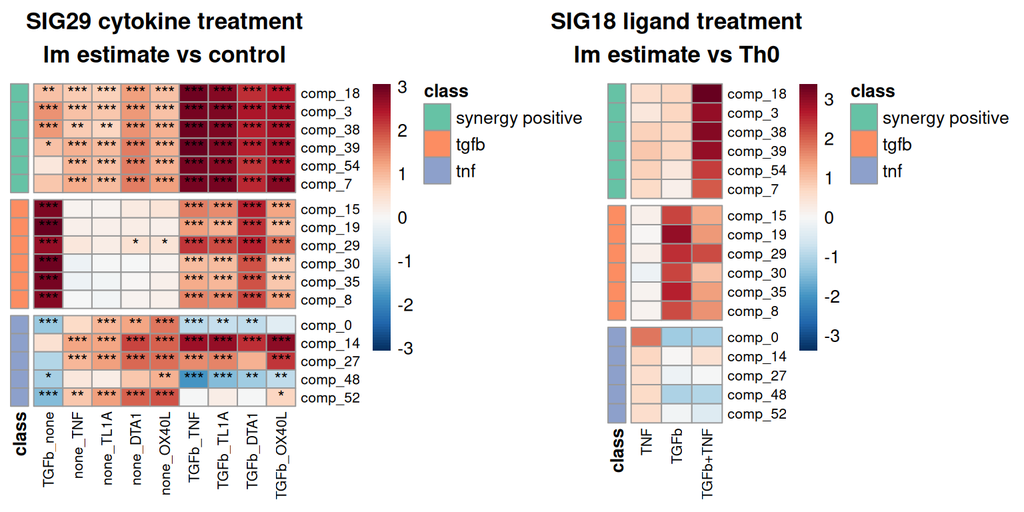

```r
hm_colors <- colorRampPalette(rev(brewer.pal(11, "RdBu")))(100)

# `mat`/`stars` already carry the intended row and column order (see above), so
# no reordering happens here. `stars = NULL` draws the panel without annotations.
plot_class_heatmap <- function(mat, title, stars = NULL) {
  max_abs   <- max(abs(mat), na.rm = TRUE)
  hm_breaks <- seq(-max_abs, max_abs, length.out = 101)
  pheatmap(mat,
           color = hm_colors, breaks = hm_breaks,
           annotation_row = ann_row,
           annotation_colors = list(class = class_colors),
           cluster_rows = FALSE, cluster_cols = FALSE,
           gaps_row = gaps_row,
           main = title,
           display_numbers = if (is.null(stars)) FALSE else stars,
           fontsize_number = 10, number_color = "black",
           fontsize_row = 8, fontsize_col = 8, silent = TRUE,
           angle_col = 90)
}

combined_hm <- arrangeGrob(
  plot_class_heatmap(mat_cond, "SIG29 cytokine treatment\nlm estimate vs control", stars_cond)$gtable,
  plot_class_heatmap(mat_sig18, "SIG18 ligand treatment\nlm estimate vs Th0")$gtable,
  ncol = 2, widths = c(1.4, 1)
)

grid.newpage()
grid.draw(combined_hm)
```

```r
pdf(file.path(out_dir, paste0("scoreHeatmap_classEstimate_SIG18vsSIG29_", score_method, ".pdf")),
    width = 8, height = 4)
grid.draw(combined_hm)
dev.off()
```

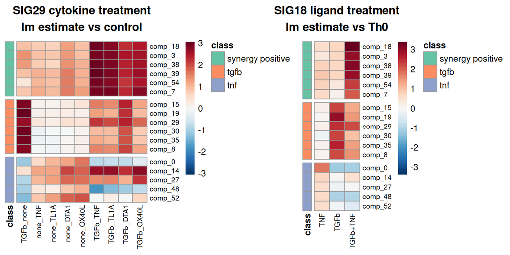

```r
combined_hm <- arrangeGrob(
  plot_class_heatmap(mat_cond, "SIG29 cytokine treatment\nlm estimate vs control")$gtable,
  plot_class_heatmap(mat_sig18, "SIG18 ligand treatment\nlm estimate vs Th0")$gtable,
  ncol = 2, widths = c(1.4, 1)
)

grid.newpage()
grid.draw(combined_hm)
```

```r
pdf(file.path(out_dir, paste0("scoreHeatmap_noStars_classEstimate_SIG18vsSIG29_", score_method, ".pdf")),
    width = 8, height = 4)
grid.draw(combined_hm)
dev.off()
```

The SIG29 panel on its own, transposed to conditions x programs for a wide figure. The program class annotation and its gaps move from rows to columns with the transpose, so `ann_row`/`gaps_row` are passed as `annotation_col`/`gaps_col`.

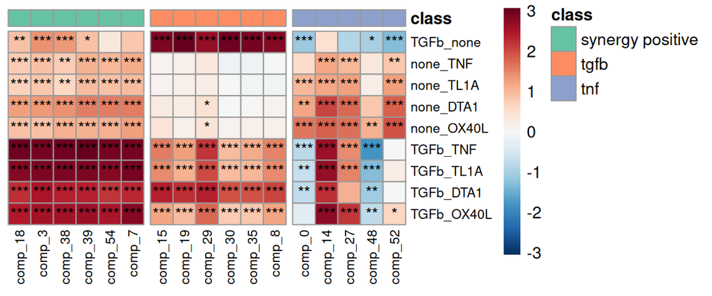

```r
max_abs   <- max(abs(mat_cond), na.rm = TRUE)
hm_breaks <- seq(-max_abs, max_abs, length.out = 101)
hm <- pheatmap(
  t(mat_cond),
  color = hm_colors, breaks = hm_breaks,
  annotation_col = ann_row,
  annotation_colors = list(class = class_colors),
  cluster_rows = FALSE, cluster_cols = FALSE,
  gaps_col = gaps_row,
  display_numbers = t(stars_cond),
  fontsize_number = 10, number_color = "black",
  fontsize_row = 8, fontsize_col = 8, angle_col = 90
)
```

```r
save_pheatmap_pdf(hm, file.path(out_dir, paste0("scoreHeatmap_classEstimate_SIG29_", score_method, ".pdf")),
                  width = 6, height = 2.5)
```

# Volcano plots (interaction effect per program)

```r
lmFit <- read_csv(sig18_lm_fit)
```

```r
volcano_interaction <- function(interaction_overlay) {
  # filter SIG18 lm results for desired overlay term
  lmInput <- lmFit %>%
    filter(term == interaction_overlay) %>%
    dplyr::select(program = component, estimate_overlay = estimate, p_adj_overlay = p_adj)

  lm_int_scored %>%
    left_join(lmInput, by = "program") %>%
    ggplot(aes(x = estimate_interaction, y = -log10(p_adj_interaction))) +
    geom_hline(yintercept = -log10(sig_alpha), lty = 2, color = "grey60") +
    geom_vline(xintercept = 0, lty = 2, color = "grey60") +
    geom_point(aes(fill = estimate_overlay, size = -log10(p_adj_overlay)), shape = 21) +
    geom_text_repel(aes(label = ifelse(interaction_class != "none", program, "")),
                    size = 2, max.overlaps = 15) +
    scale_fill_distiller(palette = "RdBu") +
    facet_wrap(~ interaction) +
    theme(aspect.ratio = 1) +
    labs(title = paste0("SIG18 programs — SIG29 (", score_method, ")"),
         x = "interaction estimate (pair term)",
         fill = paste0("estimate\n",interaction_overlay),
         size = paste0("pscore\n",interaction_overlay))
}
```

```r
overlays <- c("ligand1TGFb:ligand2TNF", "ligand1TGFb", "ligand2TNF")
volcano_plots <- setNames(purrr::map(overlays, volcano_interaction), overlays)
```

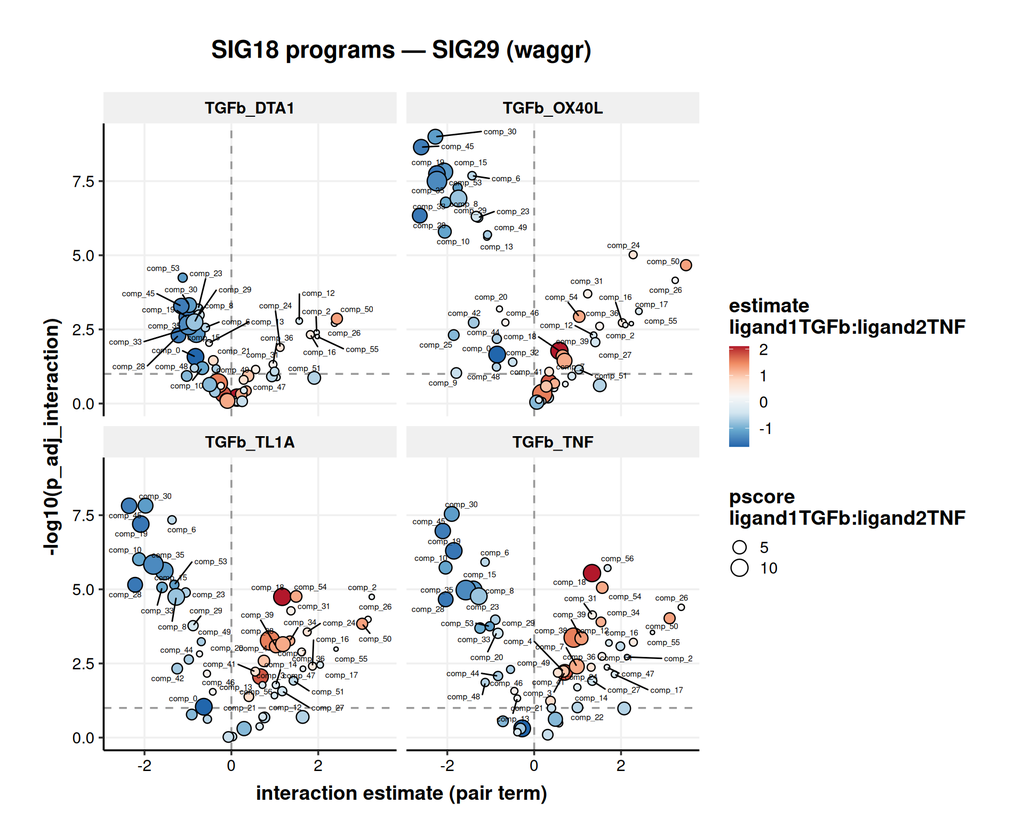

```r
volcano_plots[["ligand1TGFb:ligand2TNF"]]
```

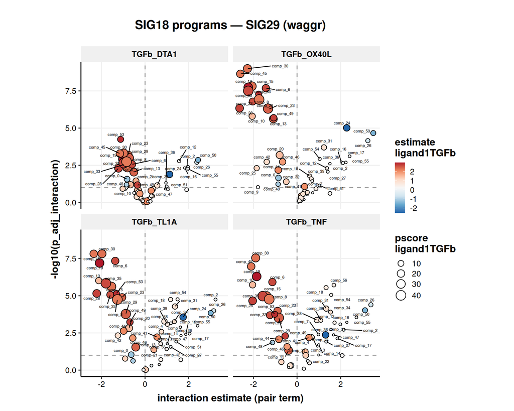

```r
volcano_plots[["ligand1TGFb"]]
```

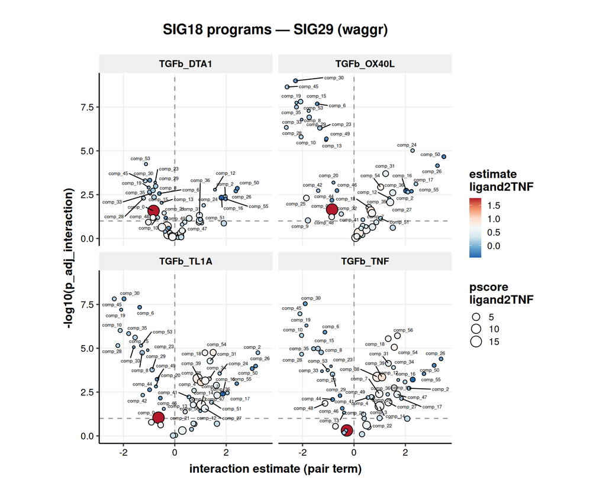

```r
volcano_plots[["ligand2TNF"]]
```

```r
for (ov in overlays) {
  ov_tag <- gsub("[^A-Za-z0-9]+", "_", ov)
  ggsave(file.path(out_dir, paste0("scoreVolcano_SIG18_", ov_tag, "_", score_method, "_SIG29.pdf")),
         volcano_plots[[ov]], width = 10, height = 8)
}
```